# bias_error2

Devin Gamble

8/24/2020

# Additional analyses on the effecto of coordinate uncertainty (error distance) on pheno-climatic models

#### Load Data

```r
nemo_df2 <- read_csv(here::here("data_cleaning", "nemo_full_1901_2019.csv")) %>%
  mutate(error_bin = as_factor(error_bin)) #Should this be ordered? #Combined specimen & climate data from 1901-2019
#1677 obs, 1251 columns

nemo_df1 <- read_csv(here::here("data_cleaning", "nemo_full_1861_2019.csv")) #Combined data for all years
#1764 obs, 1251 columns

options(contrasts = c("contr.sum", "contr.poly"))
```

Data subset by error distances/bins

```r
nemo_all_errors <- nemo_df2 %>%
  filter(!is.na(error_dist_m))
#1239 out of 1764 obs with error distance
#1166 after rm records before 1901

#0-5 km resolution
nemo_e0_5 <- nemo_all_errors %>%
  filter(error_bin == "<2 km" | error_bin == "2-5 km")

#0-4 km
nemo_e0_4 <-  nemo_all_errors %>%
  filter(error_dist_m >= 0 & error_dist_m <= 4000) #Do Not include error_bin in models

#0-2 km
nemo_e2 <- nemo_all_errors %>%
  filter(error_bin == "<2 km")
```

## Randomly sampling equal subsets of different error bins

**Bins**  
- Original Data set  
- Error Distance present  
- 0-5 km error  
- 0-2 km error

*Use some kind of statistical resampling test?* *Hit up Tadeo*

Smallest sample size is N = 743 in 0-2 km data subset. Randomly sample 743 obs from each subset and compare models.

### MAT & MAP

```r
#####
# Full Data
#####

#Set seed for consistency
#set.seed(407)

#Only MAT & MAP
#Sample 1
M100Y_sub1 <- lm(DOY ~ MAT_100Y + MAP_100Y, data = sample_n(nemo_df2, size = 743, replace = FALSE))
#Sample 2
M100Y_sub2 <- lm(DOY ~ MAT_100Y + MAP_100Y, data = sample_n(nemo_df2, size = 743, replace = FALSE))
#Sample 3
M100Y_sub3 <- lm(DOY ~ MAT_100Y + MAP_100Y, data = sample_n(nemo_df2, size = 743, replace = FALSE))
#Sample 4
M100Y_sub4 <- lm(DOY ~ MAT_100Y + MAP_100Y, data = sample_n(nemo_df2, size = 743, replace = FALSE))
#Sample 5
M100Y_sub5 <- lm(DOY ~ MAT_100Y + MAP_100Y, data = sample_n(nemo_df2, size = 743, replace = FALSE))

plot_summs(M100Y_sub1, M100Y_sub2, M100Y_sub3, M100Y_sub4, M100Y_sub5, model.names = c("og1", "og2", "og3", "og4", "og5"), scale = TRUE) + theme_bw()
```

[output not shown]

```r
#all_obs_MATMAP_models <- list(M100Y_sub1, M100Y_sub2, M100Y_sub3, M100Y_sub4, M100Y_sub5) #Cannot extract models for

#With other geography & year
#Sample 1
M100Y_sub1c <- lm(DOY ~ MAT_100Y + MAP_100Y + elev_m + long + year, data = sample_n(nemo_df2, size = 743, replace = FALSE))
#Sample 2
M100Y_sub2c <- lm(DOY ~ MAT_100Y + MAP_100Y + elev_m + long + year, data = sample_n(nemo_df2, size = 743, replace = FALSE))
#Sample 3
M100Y_sub3c <- lm(DOY ~ MAT_100Y + MAP_100Y + elev_m + long + year, data = sample_n(nemo_df2, size = 743, replace = FALSE))
#Sample 4
M100Y_sub4c <- lm(DOY ~ MAT_100Y + MAP_100Y + elev_m + long + year, data = sample_n(nemo_df2, size = 743, replace = FALSE))
#Sample 5
M100Y_sub5c <- lm(DOY ~ MAT_100Y + MAP_100Y + elev_m + long + year, data = sample_n(nemo_df2, size = 743, replace = FALSE))

plot_summs(M100Y_sub1c, M100Y_sub2c, M100Y_sub3c, M100Y_sub4c, M100Y_sub5c, model.names = c("og1", "og2", "og3", "og4", "og5"), scale = TRUE) + theme_bw()
```

[output not shown]

```r
#####
# All Errors
#####

#Only MAT & MAP
#Sample 1
M100Y_sube1 <- lm(DOY ~ MAT_100Y + MAP_100Y, data = sample_n(nemo_all_errors, size = 743, replace = FALSE))
#Sample 2
M100Y_sube2 <- lm(DOY ~ MAT_100Y + MAP_100Y, data = sample_n(nemo_all_errors, size = 743, replace = FALSE))
#Sample 3
M100Y_sube3 <- lm(DOY ~ MAT_100Y + MAP_100Y, data = sample_n(nemo_all_errors, size = 743, replace = FALSE))
#Sample 4
M100Y_sube4 <- lm(DOY ~ MAT_100Y + MAP_100Y, data = sample_n(nemo_all_errors, size = 743, replace = FALSE))
#Sample 5
M100Y_sube5 <- lm(DOY ~ MAT_100Y + MAP_100Y, data = sample_n(nemo_all_errors, size = 743, replace = FALSE))

plot_summs(M100Y_sube1, M100Y_sube2, M100Y_sube3, M100Y_sube4, M100Y_sube5, model.names = c("all_e1", "all_e2", "all_e3", "all_e4", "all_e5"), scale = TRUE) + theme_bw()
```

[output not shown]

```r
#With other geography & year
#Sample 1
M100Y_sube1c <- lm(DOY ~ MAT_100Y + MAP_100Y + elev_m + long + year, data = sample_n(nemo_all_errors, size = 743, replace = FALSE))
#Sample 2
M100Y_sube2c <- lm(DOY ~ MAT_100Y + MAP_100Y + elev_m + long + year, data = sample_n(nemo_all_errors, size = 743, replace = FALSE))
#Sample 3
M100Y_sube3c <- lm(DOY ~ MAT_100Y + MAP_100Y + elev_m + long + year, data = sample_n(nemo_all_errors, size = 743, replace = FALSE))
#Sample 4
M100Y_sube4c <- lm(DOY ~ MAT_100Y + MAP_100Y + elev_m + long + year, data = sample_n(nemo_all_errors, size = 743, replace = FALSE))
#Sample 5
M100Y_sube5c <- lm(DOY ~ MAT_100Y + MAP_100Y + elev_m + long + year, data = sample_n(nemo_all_errors, size = 743, replace = FALSE))

plot_summs(M100Y_sube1c, M100Y_sube2c, M100Y_sube3c, M100Y_sube4c, M100Y_sube5c, model.names = c("all_e1", "all_e2", "all_e3", "all_e4", "all_e5"), scale = TRUE) + theme_bw()
```

[output not shown]

```r
#####
# 0-5 km Error
#####

#Only MAT & MAP
#Sample 1
M100Y_sube51 <- lm(DOY ~ MAT_100Y + MAP_100Y, data = sample_n(nemo_e0_5, size = 743, replace = FALSE))
#Sample 2
M100Y_sube52 <- lm(DOY ~ MAT_100Y + MAP_100Y, data = sample_n(nemo_e0_5, size = 743, replace = FALSE))
#Sample 3
M100Y_sube53 <- lm(DOY ~ MAT_100Y + MAP_100Y, data = sample_n(nemo_e0_5, size = 743, replace = FALSE))
#Sample 4
M100Y_sube54 <- lm(DOY ~ MAT_100Y + MAP_100Y, data = sample_n(nemo_e0_5, size = 743, replace = FALSE))
#Sample 5
M100Y_sube55 <- lm(DOY ~ MAT_100Y + MAP_100Y, data = sample_n(nemo_e0_5, size = 743, replace = FALSE))

plot_summs(M100Y_sube51, M100Y_sube52, M100Y_sube53, M100Y_sube54, M100Y_sube55, model.names = c("0-5_1", "0-5_2", "0-5_3", "0-5_4", "0-5_5"), scale = TRUE) + theme_bw()
```

[output not shown]

```r
#With other geography & year
#Sample 1
M100Y_sube51c <- lm(DOY ~ MAT_100Y + MAP_100Y + elev_m + long + year, data = sample_n(nemo_e0_5, size = 743, replace = FALSE))
#Sample 2
M100Y_sube52c <- lm(DOY ~ MAT_100Y + MAP_100Y + elev_m + long + year, data = sample_n(nemo_e0_5, size = 743, replace = FALSE))
#Sample 3
M100Y_sube53c <- lm(DOY ~ MAT_100Y + MAP_100Y + elev_m + long + year, data = sample_n(nemo_e0_5, size = 743, replace = FALSE))
#Sample 4
M100Y_sube54c <- lm(DOY ~ MAT_100Y + MAP_100Y + elev_m + long + year, data = sample_n(nemo_e0_5, size = 743, replace = FALSE))
#Sample 5
M100Y_sube55c <- lm(DOY ~ MAT_100Y + MAP_100Y + elev_m + long + year, data = sample_n(nemo_e0_5, size = 743, replace = FALSE))

plot_summs(M100Y_sube51c, M100Y_sube52c, M100Y_sube53c, M100Y_sube54c, M100Y_sube55c, model.names = c("0-5_1", "0-5_2", "0-5_3", "0-5_4", "0-5_5"), scale = TRUE) + theme_bw()
```

[output not shown]

```r
#####
# 0-2 km Error
#####
M100Y_sube21 <- lm(DOY ~ MAT_100Y + MAP_100Y, data = nemo_e2)

M100Y_sube21c <- lm(DOY ~ MAT_100Y + MAP_100Y + elev_m + long + year, data = nemo_e2)
```

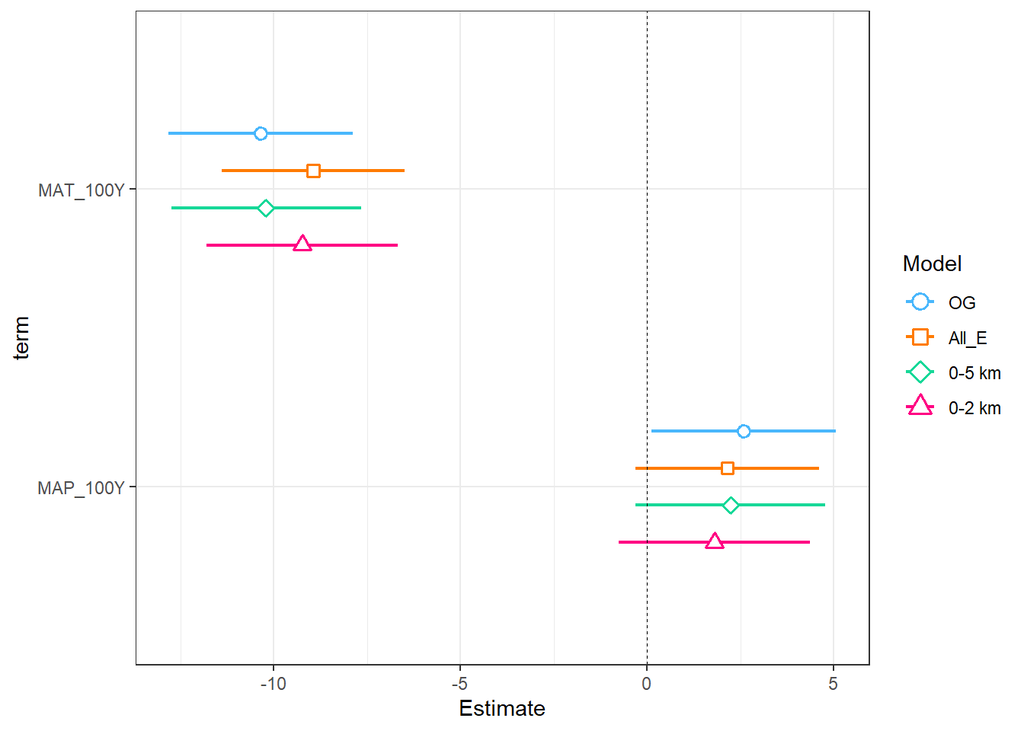

```r
#Compare different subsets...

#Assign multiple models (different samples of same data) to a vector and randomly draw from them to plot? Doesn't work with lists


plot_summs(M100Y_sub1, M100Y_sube1, M100Y_sube51, M100Y_sube21, model.names = c("OG", "All_E", "0-5 km", "0-2 km"), scale = TRUE) + theme_bw()
```

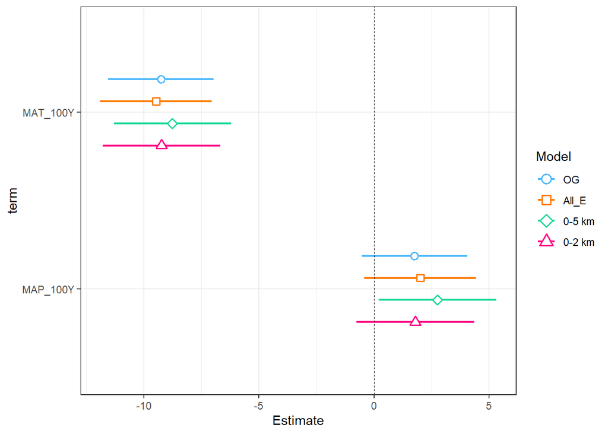

```r
plot_summs(M100Y_sub2, M100Y_sube2, M100Y_sube52, M100Y_sube21, model.names = c("OG", "All_E", "0-5 km", "0-2 km"), scale = TRUE) + theme_bw()
```

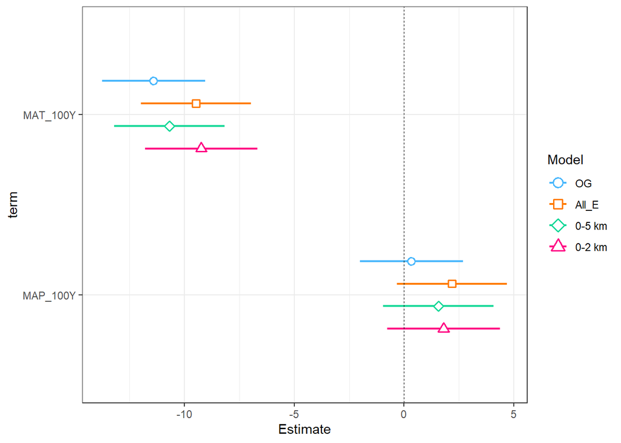

```r
plot_summs(M100Y_sub3, M100Y_sube3, M100Y_sube53, M100Y_sube21, model.names = c("OG", "All_E", "0-5 km", "0-2 km"), scale = TRUE) + theme_bw()
```

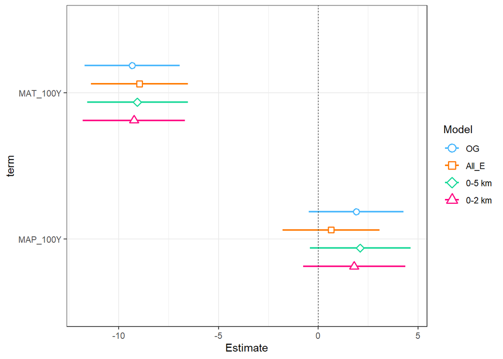

```r
plot_summs(M100Y_sub4, M100Y_sube4, M100Y_sube54, M100Y_sube21, model.names = c("OG", "All_E", "0-5 km", "0-2 km"), scale = TRUE) + theme_bw()
```

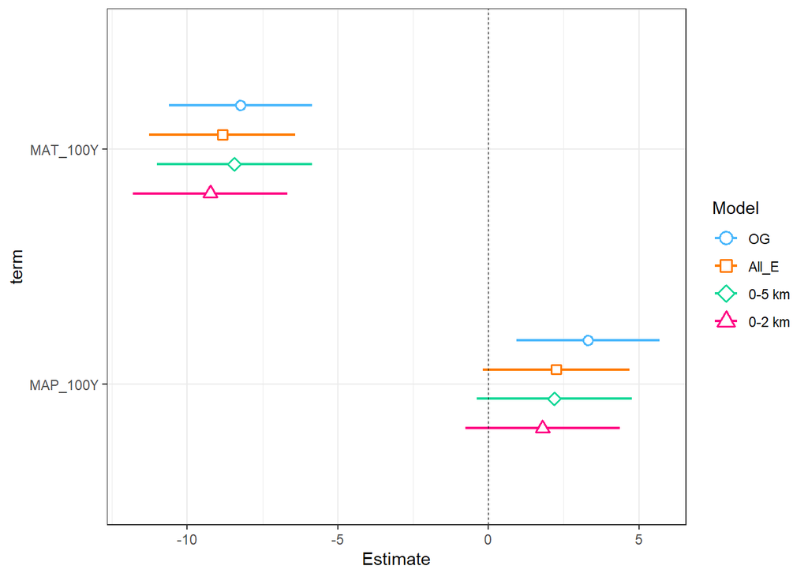

```r
plot_summs(M100Y_sub5, M100Y_sube5, M100Y_sube55, M100Y_sube21, model.names = c("OG", "All_E", "0-5 km", "0-2 km"), scale = TRUE) + theme_bw()
```

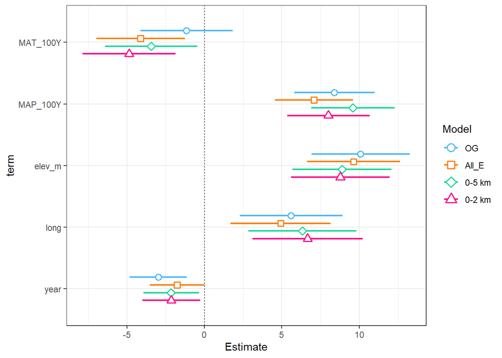

```r
#All covariates
plot_summs(M100Y_sub1c, M100Y_sube1c, M100Y_sube51c, M100Y_sube21c, model.names = c("OG", "All_E", "0-5 km", "0-2 km"), scale = TRUE) + theme_bw()
```

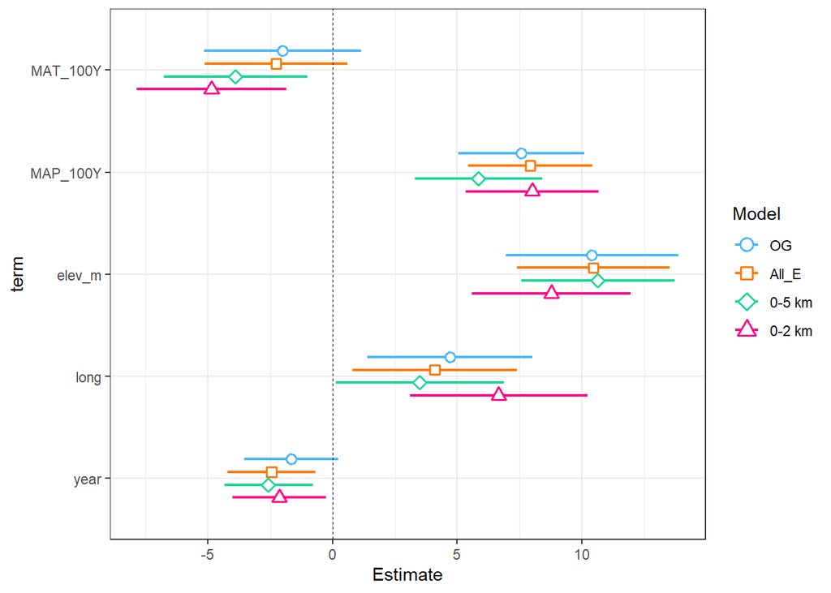

```r
plot_summs(M100Y_sub2c, M100Y_sube2c, M100Y_sube52c, M100Y_sube21c, model.names = c("OG", "All_E", "0-5 km", "0-2 km"), scale = TRUE) + theme_bw()
```

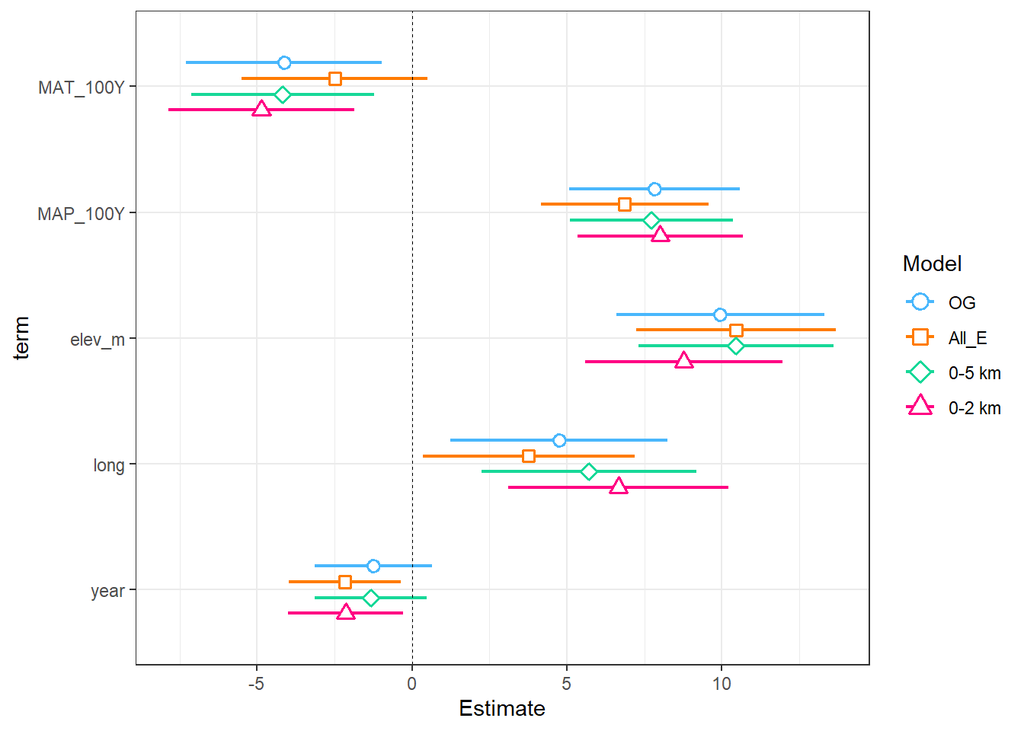

```r
plot_summs(M100Y_sub3c, M100Y_sube3c, M100Y_sube53c, M100Y_sube21c, model.names = c("OG", "All_E", "0-5 km", "0-2 km"), scale = TRUE) + theme_bw()
```

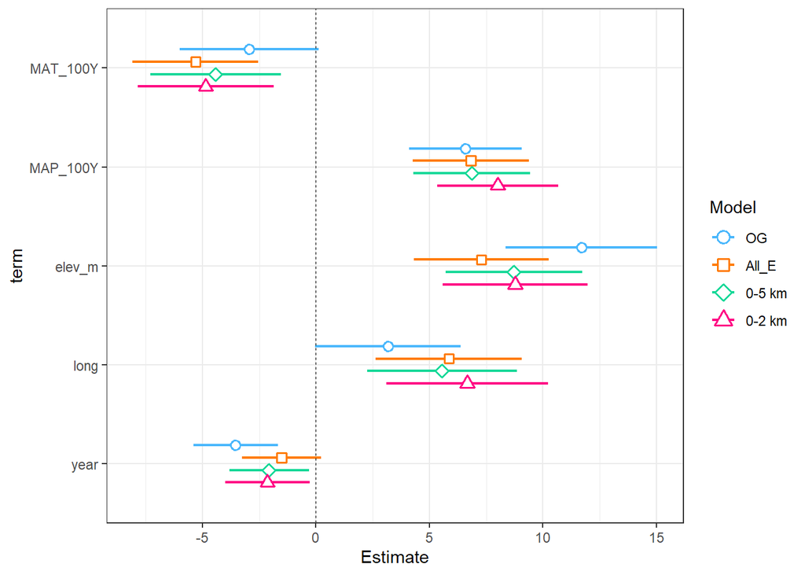

```r
plot_summs(M100Y_sub4c, M100Y_sube4c, M100Y_sube54c, M100Y_sube21c, model.names = c("OG", "All_E", "0-5 km", "0-2 km"), scale = TRUE) + theme_bw()
```

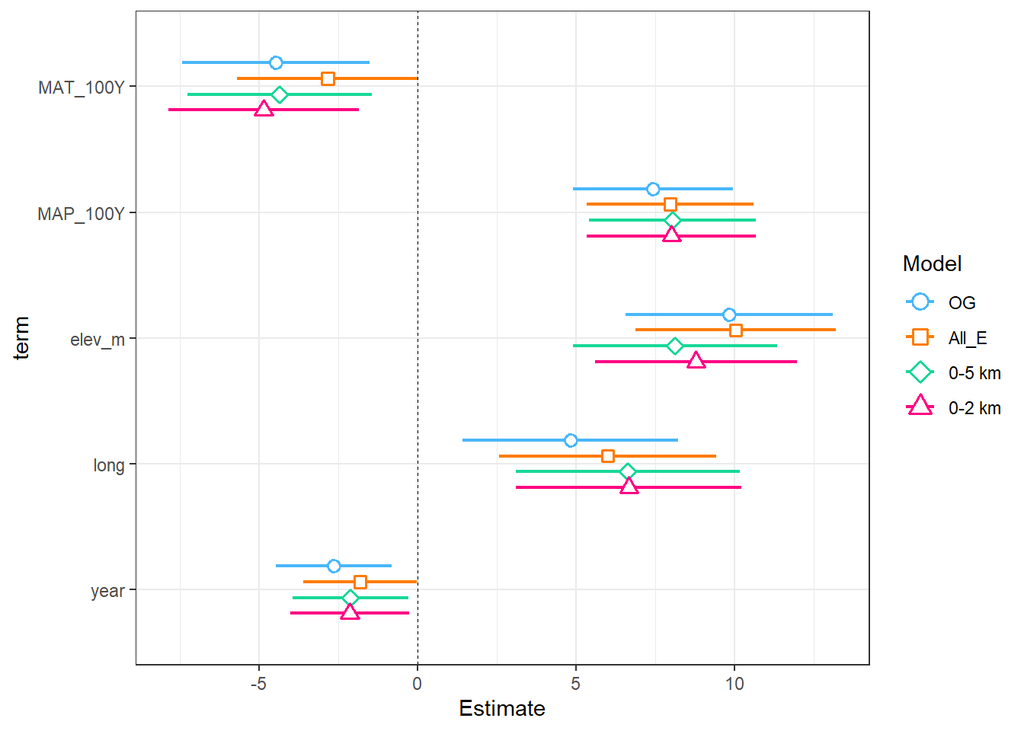

```r
plot_summs(M100Y_sub5c, M100Y_sube5c, M100Y_sube55c, M100Y_sube21c, model.names = c("OG", "All_E", "0-5 km", "0-2 km"), scale = TRUE) + theme_bw()
```

```r
#Summary Table with multiple models
#Compare different error classes, or random samples of the same class?

###
#! Gets tricky to read with 9+ models...!
###
export_summs(M100Y_sub1, M100Y_sube1, M100Y_sube51, M100Y_sube21, model.names = c("OG", "All_E", "0-5 km", "0-2 km"), scale = TRUE, error_format = "[{conf.low}, {conf.high}]",
             coefs = c("MAT_100Y", "MAP_100Y")) #exclude intercept coefficients
```

|  | OG | All_E | 0-5 km | 0-2 km |
| --- | --- | --- | --- | --- |
| MAT_100Y | -10.35 *** | -8.94 *** | -10.21 *** | -9.24 *** |
|  | [-12.81, -7.88] | [-11.39, -6.49] | [-12.75, -7.67] | [-11.80, -6.68] |
| MAP_100Y | 2.58 * | 2.15 | 2.23 | 1.80 |
|  | [0.12, 5.05] | [-0.31, 4.60] | [-0.31, 4.77] | [-0.76, 4.36] |
| N | 743 | 743 | 743 | 743 |
| R2 | 0.16 | 0.14 | 0.15 | 0.12 |
| All continuous predictors are mean-centered and scaled by 1 standard deviation. *** p < 0.001; ** p < 0.01; * p < 0.05. |  |  |  |  |

```r
             #save to file arg doesn't work well

export_summs(M100Y_sub2, M100Y_sube2, M100Y_sube52, M100Y_sube21, model.names = c("OG", "All_E", "0-5 km", "0-2 km"), scale = TRUE, error_format = "[{conf.low}, {conf.high}]", coefs = c("MAT_100Y", "MAP_100Y"))
```

|  | OG | All_E | 0-5 km | 0-2 km |
| --- | --- | --- | --- | --- |
| MAT_100Y | -9.26 *** | -9.48 *** | -8.76 *** | -9.24 *** |
|  | [-11.55, -6.98] | [-11.91, -7.05] | [-11.31, -6.20] | [-11.80, -6.68] |
| MAP_100Y | 1.77 | 2.01 | 2.77 * | 1.80 |
|  | [-0.52, 4.06] | [-0.42, 4.44] | [0.21, 5.32] | [-0.76, 4.36] |
| N | 743 | 743 | 743 | 743 |
| R2 | 0.14 | 0.14 | 0.13 | 0.12 |
| All continuous predictors are mean-centered and scaled by 1 standard deviation. *** p < 0.001; ** p < 0.01; * p < 0.05. |  |  |  |  |

```r
export_summs(M100Y_sub3, M100Y_sube3, M100Y_sube53, M100Y_sube21, model.names = c("OG", "All_E", "0-5 km", "0-2 km"), scale = TRUE, error_format = "[{conf.low}, {conf.high}]", coefs = c("MAT_100Y", "MAP_100Y"))
```

|  | OG | All_E | 0-5 km | 0-2 km |
| --- | --- | --- | --- | --- |
| MAT_100Y | -11.40 *** | -9.47 *** | -10.69 *** | -9.24 *** |
|  | [-13.74, -9.06] | [-11.98, -6.97] | [-13.21, -8.17] | [-11.80, -6.68] |
| MAP_100Y | 0.34 | 2.18 | 1.57 | 1.80 |
|  | [-2.00, 2.68] | [-0.32, 4.69] | [-0.95, 4.09] | [-0.76, 4.36] |
| N | 743 | 743 | 743 | 743 |
| R2 | 0.16 | 0.14 | 0.16 | 0.12 |
| All continuous predictors are mean-centered and scaled by 1 standard deviation. *** p < 0.001; ** p < 0.01; * p < 0.05. |  |  |  |  |

```r
export_summs(M100Y_sub4, M100Y_sube4, M100Y_sube54, M100Y_sube21, model.names = c("OG", "All_E", "0-5 km", "0-2 km"), scale = TRUE, error_format = "[{conf.low}, {conf.high}]", coefs = c("MAT_100Y", "MAP_100Y"))
```

|  | OG | All_E | 0-5 km | 0-2 km |
| --- | --- | --- | --- | --- |
| MAT_100Y | -9.33 *** | -8.96 *** | -9.06 *** | -9.24 *** |
|  | [-11.71, -6.95] | [-11.39, -6.53] | [-11.58, -6.53] | [-11.80, -6.68] |
| MAP_100Y | 1.90 | 0.65 | 2.11 | 1.80 |
|  | [-0.48, 4.28] | [-1.78, 3.08] | [-0.42, 4.63] | [-0.76, 4.36] |
| N | 743 | 743 | 743 | 743 |
| R2 | 0.14 | 0.11 | 0.13 | 0.12 |
| All continuous predictors are mean-centered and scaled by 1 standard deviation. *** p < 0.001; ** p < 0.01; * p < 0.05. |  |  |  |  |

```r
export_summs(M100Y_sub5, M100Y_sube5, M100Y_sube55, M100Y_sube21, model.names = c("OG", "All_E", "0-5 km", "0-2 km"), scale = TRUE, error_format = "[{conf.low}, {conf.high}]", coefs = c("MAT_100Y", "MAP_100Y"))
```

|  | OG | All_E | 0-5 km | 0-2 km |
| --- | --- | --- | --- | --- |
| MAT_100Y | -8.23 *** | -8.83 *** | -8.43 *** | -9.24 *** |
|  | [-10.61, -5.85] | [-11.26, -6.40] | [-11.01, -5.85] | [-11.80, -6.68] |
| MAP_100Y | 3.31 ** | 2.25 | 2.19 | 1.80 |
|  | [0.93, 5.69] | [-0.18, 4.68] | [-0.38, 4.77] | [-0.76, 4.36] |
| N | 743 | 743 | 743 | 743 |
| R2 | 0.13 | 0.13 | 0.12 | 0.12 |
| All continuous predictors are mean-centered and scaled by 1 standard deviation. *** p < 0.001; ** p < 0.01; * p < 0.05. |  |  |  |  |

## Randomly disperesed coordinates (lat/long) by a set error distance

How would varying point coordinates by different error distances affect pheno-climatic models?

Determining new coordinates based on km will depend on the present latitude and longitude of a collection. Use the WGS84 ellipsoid to calculate new decimal degrees based on some km deviation at each record (majority of georeference datum are WGS 84, some NAD83 and NAD27). Calculating Great-circle distances: the ‘Haversine’ formula is one method that could be reverse-engineered to find the decimal degrees for a new point coordinate some km away from a first coordinate. Another is the Vincenty formula, which is more appropriate for very large distances.

Potentially helpful packages:  
- geosphere (distm, distHaversine) - GeoRange (deg2rad, gcd_hf/vif) - SpatialEpi (latlong2grid)

Assign new coordinates

```r
nemo_recs <- nemo_df1 %>%
  select(specimen_number:mature_5)

#Error dist = 2
nemo_randcoords_2km <- nemo_recs



#Standardized csv for ClimateNA
```